# Analiza transakcyjnych czasów trwania oraz czasów trwania ceny dla spółki H i spółki L

Jakub Morawski, Paweł Modzelewski

2026-01-21

# 1. Transakcyjne czasy trwania

## 1.1. Wgranie i przygotowanie danych

```r
daneH <- read.csv("spolkaH.csv", dec=".", sep=";")
daneL <- read.csv("spolkaL.csv", dec=".", sep=";")

convert_to_datetime <- function(df){
  date_str <- sprintf("%s-%s-%s",
                      substr(df$daty, 1, 4),
                      substr(df$daty, 5, 6),
                      substr(df$daty, 7, 8))
  time_str <- sprintf("%02d:%02d:%02d",
                      as.integer(df$godz/10000),
                      as.integer((df$godz %% 10000) / 100),
                      df$godz %% 100)
  df$datetime <- ymd_hms(paste(date_str, time_str))
  return(df)
}

daneH <- convert_to_datetime(daneH)
daneL <- convert_to_datetime(daneL)

start_date <- as.POSIXct("2019-01-01 00:00:00")
end_date   <- as.POSIXct("2019-06-30 00:00:00")

daneH <- daneH %>% filter(datetime >= start_date & datetime <= end_date + days(1) - seconds(1))
daneL <- daneL %>% filter(datetime >= start_date & datetime <= end_date + days(1) - seconds(1))

filter_trading_hours <- function(df){
  start <- hms("09:00:00")
  end <- hms("16:50:00")

  df$time <- hms(format(df$datetime, "%H:%M:%S"))

  df <- df %>%
    filter(time >= start, time <= end)

  return(df)
}

daneH <- filter_trading_hours(daneH)
daneL <- filter_trading_hours(daneL)

daneH <- daneH %>% arrange(datetime)
daneL <- daneL %>% arrange(datetime)

head(daneL) %>%
  kbl(caption="Dane dla spółki L") %>%
  kable_styling(bootstrap_options = c("striped", "hover", "condensed", "responsive"))
```

Dane dla spółki L

| daty | godz | cena | vol | datetime | time |
| --- | --- | --- | --- | --- | --- |
| 20190102 | 90001 | 3.4 | 2000 | 2019-01-02 09:00:01 | 9H 0M 1S |
| 20190102 | 90001 | 3.4 | 1000 | 2019-01-02 09:00:01 | 9H 0M 1S |
| 20190102 | 90001 | 3.4 | 175 | 2019-01-02 09:00:01 | 9H 0M 1S |
| 20190102 | 90001 | 3.4 | 1000 | 2019-01-02 09:00:01 | 9H 0M 1S |
| 20190102 | 90001 | 3.4 | 1000 | 2019-01-02 09:00:01 | 9H 0M 1S |
| 20190102 | 90001 | 3.4 | 3933 | 2019-01-02 09:00:01 | 9H 0M 1S |

```r
head(daneH) %>%
  kbl(caption="Dane dla spółki H") %>%
  kable_styling(bootstrap_options = c("striped", "hover", "condensed", "responsive"))
```

Dane dla spółki H

| daty | godz | cena | vol | datetime | time |
| --- | --- | --- | --- | --- | --- |
| 20190102 | 90001 | 8.3 | 1262 | 2019-01-02 09:00:01 | 9H 0M 1S |
| 20190102 | 90001 | 8.3 | 738 | 2019-01-02 09:00:01 | 9H 0M 1S |
| 20190102 | 90001 | 8.3 | 216 | 2019-01-02 09:00:01 | 9H 0M 1S |
| 20190102 | 90001 | 8.3 | 627 | 2019-01-02 09:00:01 | 9H 0M 1S |
| 20190102 | 90001 | 8.3 | 96 | 2019-01-02 09:00:01 | 9H 0M 1S |
| 20190102 | 90001 | 8.3 | 100 | 2019-01-02 09:00:01 | 9H 0M 1S |

Załadowaliśmy dane dla spółek H i L i ograniczyliśmy je poprawnie dla okresu od 2019-01-01 do 2019-06-30, biorąc pod uwagę jedynie godziny 9:00-16:50.

## 1.2. Agregacja danych do mierzonych w równych odstępach czasu

```r
daneH_sekunda <- daneH %>%
  mutate(
    datetime_sekunda = round_date(datetime, "second"),
    wartosc = cena*vol
  ) %>%
  group_by(datetime_sekunda) %>%
  summarise(
    cena = sum(cena*vol, na.rm=T) / sum(vol, na.rm=T),
    vol = sum(vol, na.rm=T),
    wartosc = sum(wartosc, na.rm=T),
    n = n(),
    .groups = "drop"
  ) %>%
  rename(datetime = datetime_sekunda) %>%
  filter(!is.na(cena), cena>0)

daneL_sekunda <- daneL %>%
  mutate(
    datetime_sekunda = round_date(datetime, "second"),
    wartosc = cena*vol
  ) %>%
  group_by(datetime_sekunda) %>%
  summarise(
    cena = sum(cena*vol, na.rm=T) / sum(vol, na.rm=T),
    vol = sum(vol, na.rm=T),
    wartosc = sum(wartosc, na.rm=T),
    n = n(),
    .groups = "drop"
  ) %>%
  rename(datetime = datetime_sekunda) %>%
  filter(!is.na(cena), cena>0)

head(daneH_sekunda) %>%
  kbl(caption="Dane agregowane do sekundy dla spółki H") %>%
  kable_styling(bootstrap_options = c("striped", "hover", "condensed", "responsive"))
```

Dane agregowane do sekundy dla spółki H

| datetime | cena | vol | wartosc | n |
| --- | --- | --- | --- | --- |
| 2019-01-02 09:00:01 | 8.299276 | 14477 | 120148.62 | 34 |
| 2019-01-02 09:00:02 | 8.268738 | 2234 | 18472.36 | 5 |
| 2019-01-02 09:00:03 | 8.250519 | 2582 | 21302.84 | 7 |
| 2019-01-02 09:00:09 | 8.250000 | 708 | 5841.00 | 2 |
| 2019-01-02 09:00:14 | 8.250000 | 1766 | 14569.50 | 2 |
| 2019-01-02 09:01:01 | 8.250000 | 4949 | 40829.25 | 3 |

```r
head(daneL_sekunda) %>%
  kbl(caption="Dane agregowane do sekundy dla spółki L") %>%
  kable_styling(bootstrap_options = c("striped", "hover", "condensed", "responsive"))
```

Dane agregowane do sekundy dla spółki L

| datetime | cena | vol | wartosc | n |
| --- | --- | --- | --- | --- |
| 2019-01-02 09:00:01 | 3.4 | 77954 | 265043.6 | 52 |
| 2019-01-02 09:00:02 | 3.4 | 1589 | 5402.6 | 3 |
| 2019-01-02 09:00:03 | 3.4 | 1364 | 4637.6 | 3 |
| 2019-01-02 09:00:04 | 3.4 | 225 | 765.0 | 1 |
| 2019-01-02 09:00:09 | 3.4 | 228 | 775.2 | 1 |
| 2019-01-02 09:00:10 | 3.4 | 228 | 775.2 | 1 |

Dokonaliśmy agregacji danych transakcyjnych do danych mierzonych w równych odstępach jednosekundowych. Wszystkie transakcje występujące w tym samym czasie połączyliśmy w jedne, przy czym cena odpowiadająca nowej transakcji została obliczona jako średnia ważona cen poszczególnych transakcji, stosując jako wagi ich wolumeny.

## 1.3. Obliczenie transakcyjnych czasów trwania

```r
calculate_durations <- function(df){

  df$date <- as.Date(df$datetime)

  df <- df %>%
    arrange(datetime) %>%
    group_by(date) %>%
    mutate(
      duration = as.numeric(difftime(datetime, lag(datetime, default = NA), units = "secs")) #NA sprawia że pierwsze czasy trwania w sesji które byłyby zerami zostają usunięte
    ) %>%
    ungroup()


  df <- df %>% filter(duration <= 3600)

  return(df)
}

daneH_dur <- calculate_durations(daneH_sekunda)
daneL_dur <- calculate_durations(daneL_sekunda)

head(daneH_dur) %>%
  kbl(caption="Dane dla spółki L") %>%
  kable_styling(bootstrap_options = c("striped", "hover", "condensed", "responsive"))
```

| datetime | cena | vol | wartosc | n | date | duration |
| --- | --- | --- | --- | --- | --- | --- |
| 2019-01-02 09:00:02 | 8.268738 | 2234 | 18472.36 | 5 | 2019-01-02 | 1 |
| 2019-01-02 09:00:03 | 8.250519 | 2582 | 21302.84 | 7 | 2019-01-02 | 1 |
| 2019-01-02 09:00:09 | 8.250000 | 708 | 5841.00 | 2 | 2019-01-02 | 6 |
| 2019-01-02 09:00:14 | 8.250000 | 1766 | 14569.50 | 2 | 2019-01-02 | 5 |
| 2019-01-02 09:01:01 | 8.250000 | 4949 | 40829.25 | 3 | 2019-01-02 | 47 |
| 2019-01-02 09:03:02 | 8.260000 | 5114 | 42241.64 | 5 | 2019-01-02 | 121 |

```r
head(daneL_dur) %>%
  kbl(caption="Dane dla spółki H") %>%
  kable_styling(bootstrap_options = c("striped", "hover", "condensed", "responsive"))
```

| datetime | cena | vol | wartosc | n | date | duration |
| --- | --- | --- | --- | --- | --- | --- |
| 2019-01-02 09:00:02 | 3.4 | 1589 | 5402.6 | 3 | 2019-01-02 | 1 |
| 2019-01-02 09:00:03 | 3.4 | 1364 | 4637.6 | 3 | 2019-01-02 | 1 |
| 2019-01-02 09:00:04 | 3.4 | 225 | 765.0 | 1 | 2019-01-02 | 1 |
| 2019-01-02 09:00:09 | 3.4 | 228 | 775.2 | 1 | 2019-01-02 | 5 |
| 2019-01-02 09:00:10 | 3.4 | 228 | 775.2 | 1 | 2019-01-02 | 1 |
| 2019-01-02 09:00:14 | 3.4 | 1133 | 3852.2 | 3 | 2019-01-02 | 4 |

Dodaliśmy do danych kolumnę z transakcyjnymi czasami trwania (`duration`), przy czym pierwsze transakcje podczas każdej sesji, dla których czas trwania nie ma sensu (wychodziłby o wartości 0), zostały usunięte. Były to 123 obserwacje, co stanowi niecałe 0,1% danych dla spółki H, a ok. 0,15% danych dla spółki L.

## 1.4. Statystyki opisowe transakcyjnych czasów trwania

```r
stats <- function(data, name){
  stats_df <-  data.frame(
    Spółka = name,
    Średnia = as.numeric(mean(data$duration, na.rm = TRUE)),
    Mediana = as.numeric(median(data$duration, na.rm = TRUE)),
    `Odch stand.` = as.numeric(sd(data$duration, na.rm = TRUE)),
    `Wsp zmienności.` = as.numeric(sd(data$duration, na.rm = TRUE)/mean(data$duration, na.rm = TRUE)),
    Minimum = as.numeric(min(data$duration, na.rm = TRUE)),
    Maksimum = as.numeric(max(data$duration, na.rm = TRUE)),
    Skośność = as.numeric(skewness(data$duration, na.rm = TRUE)),
    Kurtoza = as.numeric(kurtosis(data$duration, na.rm = TRUE)),
    `Liczba obserwacji` = as.numeric(nrow(data))
  )

  return(stats_df)
}

statsH <- stats(daneH_dur, "Spółka H")
statsL <- stats(daneL_dur, "Spółka L")

stats_table <- bind_rows(statsH, statsL)
stats_table_formatted <- stats_table %>%
  mutate(across(where(is.numeric), ~round(., 2)))

kbl(stats_table_formatted, caption="Statystyki opisowe transakcyjnych czasów trwania") %>%
  kable_styling(bootstrap_options = c("striped", "hover", "condensed", "responsive"))
```

Statystyki opisowe transakcyjnych czasów trwania

| Spółka | Średnia | Mediana | Odch.stand. | Wsp.zmienności. | Minimum | Maksimum | Skośność | Kurtoza | Liczba.obserwacji |
| --- | --- | --- | --- | --- | --- | --- | --- | --- | --- |
| Spółka H | 27.17 | 8 | 47.32 | 1.74 | 1 | 1081 | 4.09 | 26.92 | 127536 |
| Spółka L | 43.14 | 18 | 71.28 | 1.65 | 1 | 1928 | 4.71 | 41.57 | 80325 |

*Wnioski:*

1. Intensywność handlu i płynność spółek
- Spółka H charakteryzuje się wyższą częstotliwością transakcji (127536 obserwacji, a 80325 obserwacji), co wskazuje na wyższą płynność.
- Mimo niższej średniej czasu trwania dla spółki H, to patrząc na medianę można dojść do wniosku dominacji krótkich przerw, bo połowa interwałów trwa mniej niż 8 sekund, przy jednoczesnej przeciętnej długości interwału ponad 3-krotnie większym od mediany. W przypadku spółki L ten stosunek to mniej, bo ponad 2.
2. Skrajna prawostronna skośność obu rozkładów
- Obie spółki wykazują silną dodatnią skośność (dla H: 4,09; dla L: 4,71), co jest typowe dla transakcyjnych czasów trwania.
- Mediany, co już wspomniane, osiągają wartości znacznie poniżej średnich.
- Wartości maksymalne sugerują skalę sporadycznych długich przerw (na co wskazuje różnica między medianą i średnią)
3. Ekstremalna kurtoza
- Obie spółki prezentują bardzo wysokie wartości kurtozy (dla H: 26,92; dla L: 41,57), co wskazuje na:
  - Nadmierną koncentrację danych w okolicy mediany
  - Częstsze, niż w rozkładzie normalnym ekstremalne wartości, czyli długie przerwy między transakcjami
  - Charakterystyczną dla danych rynkowych nadmierną zmienność warunkową.
- Wyższa kurtoza spółki L sugeruje większą koncentrację ekstremów, co sprawia, że handel jest mniej regularny niż w przypadku spółki H.
4. Zmienność i nieciągłość handlu
- Odchylenie standardowe spółki L jest większe niż spółki H, co przy jednoczesnej większej średniej wskazuje na większą niestabilność tempa transakcji.
- Wartości współczynników zmienności (dla H: 1,74; dla L: 1,65) sugerują, że pomimo wyższej bezwzględnej zmienności, spółka L wykazuje bardziej przewidywalny, choć wolniejszy rytm transakcji

## 1.5. Analiza sezonowości śróddziennej

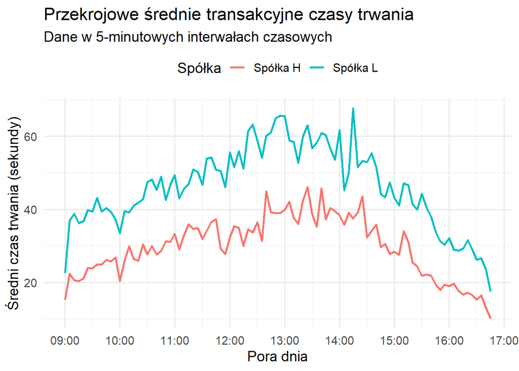

```r
calculate_5min_avgs <- function(df){
  df$interval <- floor_date(df$datetime, "5 minutes")

  df <- df %>%
    mutate(interval = if_else(hour(interval) == 16 & minute(interval) == 50,
           interval - minutes(5),
           interval))

  df$time_of_day <- hms::hms(
    hour = hour(df$datetime),
    minute = minute(df$datetime),
    second = second(df$datetime)
  )

  interval_avgs <- df %>%
    mutate(interval_time = format(interval, "%H:%M")) %>%
    group_by(interval_time) %>%
    summarise(
      avg_duration = mean(duration, na.rm=T),
      n_observations = n()
      ) %>%
    ungroup()

  interval_avgs$time_of_day <- hms::as_hms(paste0(interval_avgs$interval_time, ":00"))

  return(interval_avgs)
}

intervals_H <- calculate_5min_avgs(daneH_dur)
intervals_L <- calculate_5min_avgs(daneL_dur)

intervals_H$Spółka <- "Spółka H"
intervals_L$Spółka <- "Spółka L"
combined_intervals <- bind_rows(intervals_H, intervals_L)

ggplot(combined_intervals, aes(x = time_of_day, y=avg_duration, color=Spółka)) +
  geom_line(size=1) +
  scale_x_time(breaks = scales::breaks_width("1 hour"), labels = scales::label_time(format = "%H:%M")) +
  labs(
    title = "Przekrojowe średnie transakcyjne czasy trwania",
    subtitle = "Dane w 5-minutowych interwałach czasowych",
    x = "Pora dnia",
    y = "Średni czas trwania (sekundy)",
    color = "Spółka"
  ) +
  theme_minimal(base_size = 14) +
  theme(legend.position = "top")
```

*Wnioski:*

- Wykresy sezonowości śróddziennej mają charakterystyczny kształt przybliżony do odwróconej litery U. Na początku sesji oraz przed zamknięciem średnie transakcyjne czasy trwania zarówno dla spółki H jak i spółki L są najkrótsze.
- Wzrost średniego czasu trwania do południa spowodowany jest przez mniejszą intensywność handlu w południowych godzinach, wynikłą z przerw obiadowych, czy niższej aktywności instytucjonalnej
- Te długie przerwy to główne źródło ekstremalnych obserwacji, które powodują wysoką wartość skośności i kurtozy.
- Spadek średniego czasu trwania po południu wynika ze zbliżania się do zamknięcia sesji, wzrostu nacisku transakcyjnego, a także z otwarcia w tych godzinach giełdy amerykańskiej.
- Dla spółki L widać wyraźny szczyt około godziny 14:00, dla spółki H, nie aż tak wyraźny w okolicy godziny 13:00.
- L przedstawia silniejsze wahania, czyli większą niestabilność w godzinach południowych
- Spółka H ma mniejszą amplitudę zmienności od spółki L, bo w okolicy 20s, w porównaniu do 40s. Sugeruje to, że L odznacza się większym wpływem sezonowości na wartości średniego transakcyjnego czasu trwania.
- Bez usunięcia sezonowości śróddziennej, analiza danych prowadziłaby do błędnego wniosku, że rynki są bardziej chaotyczne, niż w rzeczywistości.

## 1.5. Usunięcie śróddziennej sezonowości

### Wyznaczenie składowej sezonowej

```r
prepare_acd_data <- function(df){
  df %>%
    #filter(duration > 0) %>%
    transmute(
      durations = duration,
      time = as.POSIXct(datetime)
    )%>%
    group_by(time) %>%
    summarise(durations = sum(durations), .groups = "drop")
}

daneH_pre <- prepare_acd_data(daneH_dur)
daneL_pre <- prepare_acd_data(daneL_dur)


remove_season <- function(df) {
  adj <- diurnalAdj(
    dur = df,
    method = "FFF",
    aggregation = "weekdays",
    Q = 3
  )
  df <- df %>%
    mutate(
      adjDur = adj$adjDur,
      seasonal = durations / adjDur,
      weekday = wday(time, label = TRUE)
    )
  return(df)
}


daneH_adj <- remove_season(daneH_pre)
```

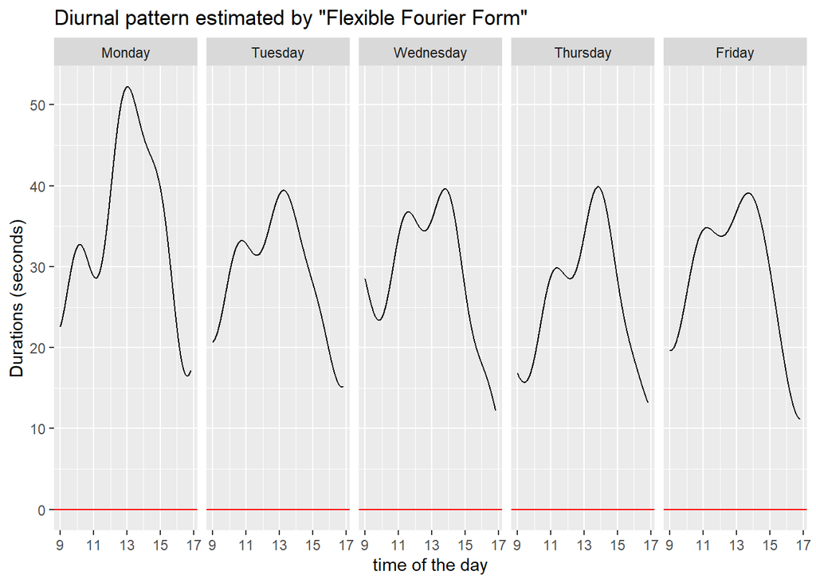

```r
daneL_adj <- remove_season(daneL_pre)
```

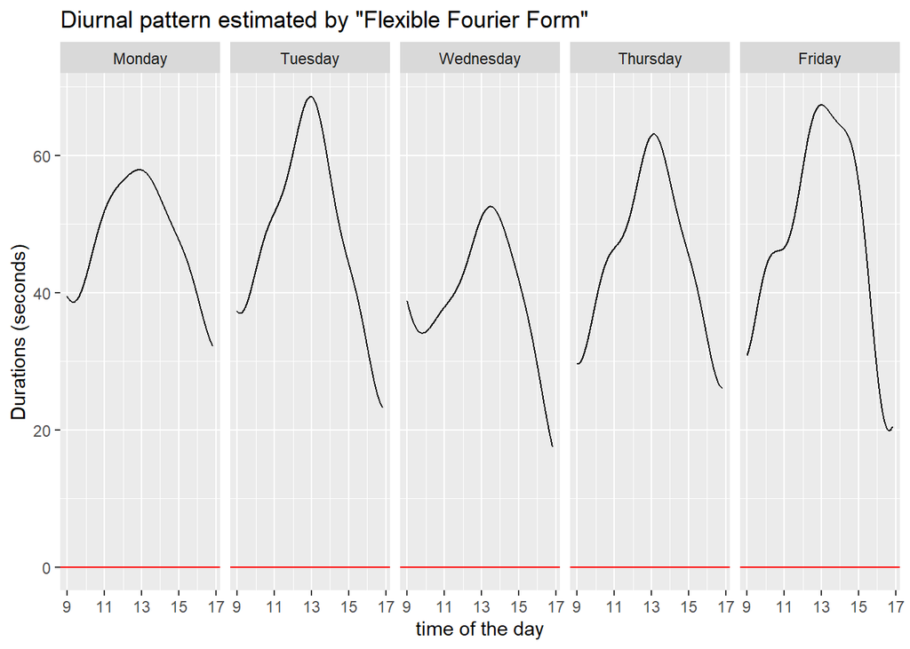

Wyznaczyliśmy szacowane, dzienne składowe sezonowe metodą za pomocą elastycznej formy Fouriera dla spółki H i L, dla każdego z dni tygodnia (w trakcie których aktywna jest giełda).

*Wnioski:*

Spółka H:

Spółka L:

Dla wszystkich wykresów szczyty znajdują się w okolicy 13:00, z powodu efektu lunchu, a po godzinie 15:00 zaliczają gwałtowny pik w dół z powodu otwarcia giełdy amerykańskiej, a także zbliżania się do końca sesji.

### Weryfikacja skuteczności usuwania sezonowości

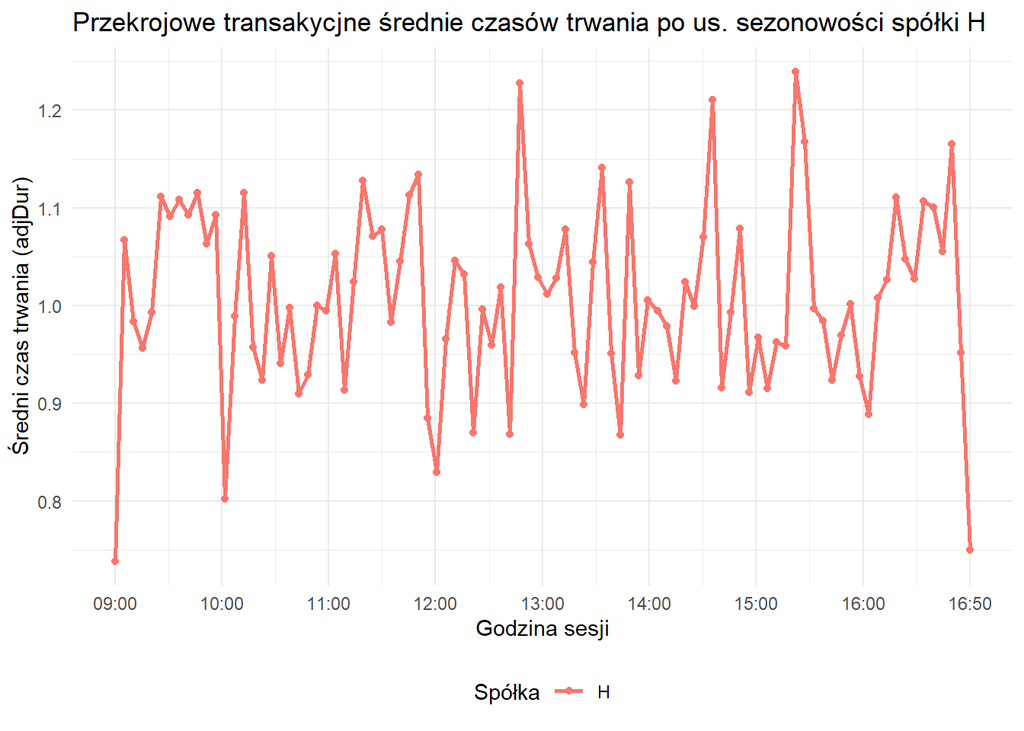

```r
aggregate_adj <- function(df, nazwa) {
  df %>%
    mutate(
      day_minute = hour(time)*60 + minute(time),
      interval_5min = floor((day_minute - 9*60)/5) + 1,
      interval_5min = ifelse(interval_5min > 94, 94, interval_5min)
    ) %>%
    group_by(interval_5min) %>%
    summarise(
      mean_time_adj = mean(adjDur, na.rm = TRUE)
    ) %>%
    mutate(Spółka = nazwa)
}

daneH_agg_season <- aggregate_adj(daneH_adj, "Spółka H")
daneL_agg_season <- aggregate_adj(daneL_adj, "Spółka L")
#results <- rbind(daneH_agg_season, daneL_agg_season)

labelsx <- c("09:00", "10:00", "11:00", "12:00", "13:00", "14:00", "15:00", "16:00", "16:50")
posH <- seq(1, max(daneH_agg_season$interval_5min), length.out = length(labelsx))
posL <- seq(1, max(daneL_agg_season$interval_5min), length.out = length(labelsx))

ggplot(daneH_agg_season, aes(x = interval_5min, y = mean_time_adj, color= "H")) +
  geom_line(size = 1) +
  geom_point() +
  scale_x_continuous(breaks = posH, labels = labelsx) +
  labs(
    title = "Przekrojowe transakycjne średnie czasów trwania po us. sezonowości spółki H",
    x = "Godzina sesji",
    y = "Średni czas trwania (adjDur)",
    color = "Spółka"
  ) +
  theme_minimal() +
  theme(legend.position = "bottom")
```

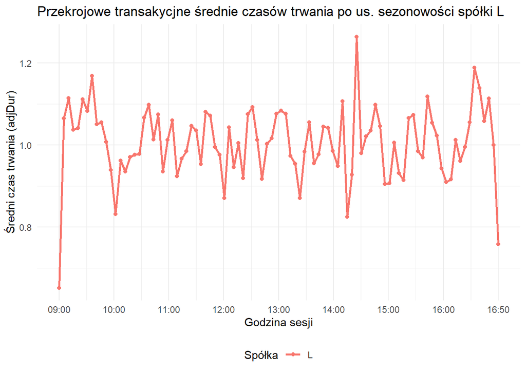

```r
ggplot(daneL_agg_season, aes(x = interval_5min, y = mean_time_adj, color= "L")) +
  geom_line(size = 1) +
  geom_point() +
  scale_x_continuous(breaks = posL, labels = labelsx) +
  labs(
    title = "Przekrojowe transakycjne średnie czasów trwania po us. sezonowości spółki L",
    x = "Godzina sesji",
    y = "Średni czas trwania (adjDur)",
    color = "Spółka"
  ) +
  theme_minimal() +
  theme(legend.position = "bottom")
```

*Analiza wykresów:*

- Wartość oczekiwana wokół 1: Na obu wykresach (dla spółki H i L) widać, że proces oscyluje wokół jedynki. To sygnał, że model sezonowości poprawnie estymuje „normę” dla danej godziny. Jeśli wartość wynosi 1, transakcja nastąpiła dokładnie w tempie, jakiego spodziewalibyśmy się o tej porze.
- Dla obu spółek większość odczytów mieści się w przedziale 0.8 – 1.2. Oznacza to, że po usunięciu trendu dobowego, zmienność (szum lub reakcje na newsy) jest relatywnie podobna dla obu podmiotów, mimo że ich bazowa płynność jest różna
- Spółka H wydaje się mieć większe skoki i spadki w wartości niż spółka L.

*Wnioski:*

Zabieg usunięcia sezonowości można uznać za udany z następujących powodów:

- Eliminacja “garbu”: Charakterystyczne wybrzuszenie w środku dnia całkowicie zniknęło. Wykresy przypominają teraz błądzenie losowe wokół wartości 1, zamiast funkcji wypukłej.
- Porównywalność: Dzięki sprowadzeniu danych do indeksu (adjDur), możemy teraz bezpośrednio porównywać dynamikę spółki H i L. Wcześniej było to trudne, bo różnica w „sekundach” zacierała obraz relatywnych skoków aktywności.
- Na końcach sesji (tuż przed 17:00) oraz na początku sesji (9:00) na obu wykresach po usunięciu sezonowości widać gwałtowne piki w dół. To wynik ogromnej zmienności, której nawet standardowe modele sezonowości nie zawsze są w stanie wygładzić w idealny sposób.

# 2. Analiza cenowych czasów trwania i modelowanie ACD/LACD

## 2.1. Wyznaczenie progu na podstawie wartości ticku dla konkretnej spółki

Zgodnie z teorią mikrostruktury rynku, czas trwania ceny definiujemy jako odstęp czasu pomiędzy momentami, w których dochodzi do skumulowanego wzrostu lub spadku ceny danego instrumentu o ustaloną wartość progową p0. Przed przystąpieniem do obliczeń, przypomnijmy ważną uwagę z wykładu:

“Przyjęcie konkretnej wartości progowej p0 determinuje własności uzyskanego procesu czasu trwania ceny. Zwykle przyjmuje się p0 jako kilku- lub kilkunastokrotność tiku cenowego.”

### Obliczenia na szeregu agregowanym do jednej sekundy

```r
old_scipen <- getOption("scipen")
options(scipen = 9999999)

clean_tick <- function(cena){
  cena <- round(cena, 6)
  roznice <- abs(diff(sort(unique(cena))))
  return(median(roznice))
}

tick_priceH <- round(clean_tick(daneH_sekunda$cena), 6)
tick_priceL <- round(clean_tick(daneL_sekunda$cena), 6)
progH <- 15*tick_priceH
progL <- 15*tick_priceL

print(paste("Mediana ticków cenowych dla spółki H:", tick_priceH))
```

```
## [1] "Mediana ticków cenowych dla spółki H: 0.000114"
```

```r
print(paste("Sugerowany próg cenowy dla spółki H:", progH, "(15-krotność ticku)"))
```

```
## [1] "Sugerowany próg cenowy dla spółki H: 0.00171 (15-krotność ticku)"
```

```r
print(paste("Mediana ticków cenowych dla spółki L:", tick_priceL))
```

```
## [1] "Mediana ticków cenowych dla spółki L: 0.000041"
```

```r
print(paste("Sugerowany próg cenowy dla spółki L:", progL, "(15-krotność ticku)"))
```

```
## [1] "Sugerowany próg cenowy dla spółki L: 0.000615 (15-krotność ticku)"
```

W wyniku agregacji danych transakcyjnych do danych mierzonych w równych odstępach jednosekundowych otrzymaliśmy szereg cenowy o wysokiej precyzji, bo aż do 6 miejsc po przecinku. Progi cenowe nie mogą być jednak tak niskie, bo ruchy na poziomie setnych części grosza nie mają znaczenia ekonomicznego, a wprowadzają do obliczeń szum mikrostruktury rynku. Progi cenowe przyjmiemy zatem zgodne z krokiem notowań danych przed agregacją (1 gr). Dla weryfikacji zasadności takiego działania przeprowadzimy powyższe obliczenia dla danych przed agregacją

### Obliczenia na szeregu przed agregacją

```r
tick_priceH <- round(clean_tick(daneH$cena), 6)
tick_priceL <- round(clean_tick(daneL$cena), 6)

print(paste("Mediana ticków cenowych dla spółki H:", tick_priceH))
```

```
## [1] "Mediana ticków cenowych dla spółki H: 0.005"
```

```r
print(paste("Sugerowany zakres progu cenowego dla spółki H: [", 10*tick_priceH, ";", 20*tick_priceH, "] (od 10-krotności do 20-krotności ticku)"))
```

```
## [1] "Sugerowany zakres progu cenowego dla spółki H: [ 0.05 ; 0.1 ] (od 10-krotności do 20-krotności ticku)"
```

```r
print(paste("Mediana ticków cenowych dla spółki L:", tick_priceL))
```

```
## [1] "Mediana ticków cenowych dla spółki L: 0.001"
```

```r
print(paste("Sugerowany zakres progu cenowego dla spółki L: [", 10*tick_priceL, ";", 20*tick_priceL, "] (od 10-krotności do 20-krotności ticku)"))
```

```
## [1] "Sugerowany zakres progu cenowego dla spółki L: [ 0.01 ; 0.02 ] (od 10-krotności do 20-krotności ticku)"
```

## 2.2. Konstrukcja szeregów czasowych cenowych czasów trwania

Na podstawie powyższej analizy, skonstruujemy dla obu spółek szeregi czasowe cenowych czasów trwania, przyjmując progi: 0.01 zł, 0.02 zł, 0.05 zł.

```r
calculate_price_durations <- function(df, p0) {
  df <- df %>% arrange(datetime) %>% mutate(date = as.Date(datetime))

  #lista na wyniki dla każdego dnia osobno (żeby nie mieszać sesji)
  results_list <- list()

  days <- unique(df$date)

  for (d in as.character(days)) {
    day_data <- df[df$date == d, ]
    n <- nrow(day_data)

    #wektory na wyniki
    keep <- logical(n)

    #punkt startowy: pierwsza transakcja dnia zawsze inicjuje proces
    keep[1] <- TRUE
    last_price <- day_data$cena[1]

    for (i in 2:n) {
      if (abs(day_data$cena[i] - last_price) >= p0) {
        keep[i] <- TRUE
        last_price <- day_data$cena[i]
      }
    }

    # Filtrujemy tylko te momenty, gdzie p0 zostało przekroczone
    day_results <- day_data[keep, ]

    # Liczymy duration między filtrowanymi momentami
    day_results <- day_results %>%
      mutate(
        duration = as.numeric(difftime(datetime, lag(datetime, default = datetime[1]), units = "secs"))
      )

    results_list[[d]] <- day_results
  }

  final_df <- bind_rows(results_list)
  return(final_df)
}
```

```r
# Obliczenie czasów trwania dla obu spółek i obu progów
# Dla Spółki H
durations_H_p01 <- calculate_price_durations(daneH_sekunda, 0.01)
durations_H_p02 <- calculate_price_durations(daneH_sekunda, 0.02)
durations_H_p05 <- calculate_price_durations(daneH_sekunda, 0.05)

# Dla Spółki L
durations_L_p01 <- calculate_price_durations(daneL_sekunda, 0.01)
durations_L_p02 <- calculate_price_durations(daneL_sekunda, 0.02)
durations_L_p05 <- calculate_price_durations(daneL_sekunda, 0.05)

# Informacje o liczbie obserwacji
cat("Czasy trwania ceny dla Spółki H:\n")
```

```
## Czasy trwania ceny dla Spółki H:
```

```r
cat("- Próg 0,01 zł:", nrow(durations_H_p01), "obserwacji\n")
```

```
## - Próg 0,01 zł: 11477 obserwacji
```

```r
cat("- Próg 0,02 zł:", nrow(durations_H_p02), "obserwacji\n")
```

```
## - Próg 0,02 zł: 3678 obserwacji
```

```r
cat("- Próg 0,05 zł:", nrow(durations_H_p05), "obserwacji\n\n")
```

```
## - Próg 0,05 zł: 654 obserwacji
```

```r
cat("Czasy trwania ceny dla Spółki L:\n")
```

```
## Czasy trwania ceny dla Spółki L:
```

```r
cat("- Próg 0,01 zł:", nrow(durations_L_p01), "obserwacji\n")
```

```
## - Próg 0,01 zł: 3723 obserwacji
```

```r
cat("- Próg 0,02 zł:", nrow(durations_L_p02), "obserwacji\n")
```

```
## - Próg 0,02 zł: 679 obserwacji
```

```r
cat("- Próg 0,05 zł:", nrow(durations_L_p05), "obserwacji\n")
```

```
## - Próg 0,05 zł: 161 obserwacji
```

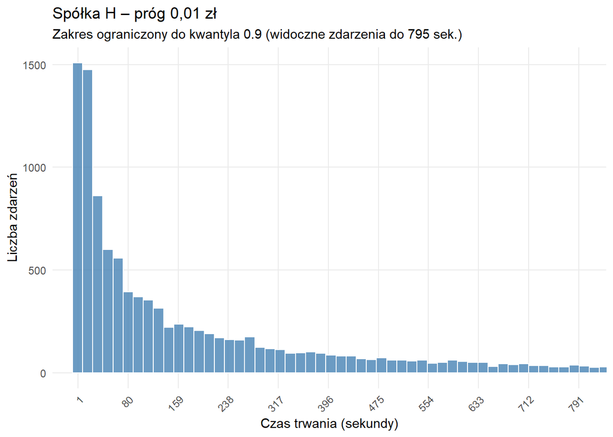

```r
# Dodanie informacji o dniu tygodnia dla późniejszej analizy
add_weekday_info <- function(df) {
  df$day_of_week <- wday(df$datetime, label = TRUE, abbr = FALSE, week_start = 1)
  return(df)
}

durations_H_p01 <- add_weekday_info(durations_H_p01)
durations_H_p02 <- add_weekday_info(durations_H_p02)
durations_H_p05 <- add_weekday_info(durations_H_p05)

durations_L_p01 <- add_weekday_info(durations_L_p01)
durations_L_p02 <- add_weekday_info(durations_L_p02)
durations_L_p05 <- add_weekday_info(durations_L_p05)



usuwanie_zer <- function(df){
  df_cleaned <- df %>%
    arrange(datetime) %>%         # Porządek chronologiczny
    group_by(as.Date(datetime)) %>% # Grupowanie po dacie
    filter(duration > 0) %>%      # Usuwanie zer (pierwszych wpisów i ewentualnych błędów)
    ungroup() %>%
    select(-`as.Date(datetime)`)   # Usunięcie tymczasowej kolumny grupującej

  return(df_cleaned)
}

durations_H_p01 <- usuwanie_zer(durations_H_p01)
durations_H_p02 <- usuwanie_zer(durations_H_p02)
durations_H_p05 <- usuwanie_zer(durations_H_p05)

durations_L_p01 <- usuwanie_zer(durations_L_p01)
durations_L_p02 <- usuwanie_zer(durations_L_p02)
durations_L_p05 <- usuwanie_zer(durations_L_p05)


plot_dynamic_duration_hist <- function(df, title) {
  #Obliczamy punkt odcięcia (90% danych zostanie na wykresie)
  #To eliminuje bardzo długie czasy trwania, które ściskają histogram do lewej
  x_limit <- quantile(df$duration, 0.9, na.rm = TRUE)

  #Dynamiczne dobieranie kroku etykiet (breaks)
  #Chcemy mieć ok. 10 etykiet na osi
  break_step <- round(x_limit / 10)
  if(break_step == 0) break_step <- 1 #Zabezpieczenie dla bardzo krótkich szeregów

  ggplot(df, aes(x = duration)) +
    geom_histogram(
      aes(y = after_stat(count)),
      binwidth = max(1, round(x_limit/50)), #Szerokość słupka dostosowana do zakresu
      fill = "steelblue",
      color = "white",
      alpha = 0.8
    ) +

    #Dynamiczne ograniczenie osi X
    coord_cartesian(xlim = c(0, x_limit)) +
    scale_x_continuous(breaks = seq(1, x_limit, by = break_step)) +
    labs(
      title = title,
      subtitle = paste("Zakres ograniczony do kwantyla 0.9 (widoczne zdarzenia do", round(x_limit), "sek.)"),
      x = "Czas trwania (sekundy)",
      y = "Liczba zdarzeń"
    ) +
    theme_minimal() +
    theme(
      axis.text.x = element_text(angle = 45, hjust = 1),
      panel.grid.minor = element_blank()
    )
}


plot_dynamic_duration_hist(durations_H_p01, "Spółka H – próg 0,01 zł")
```

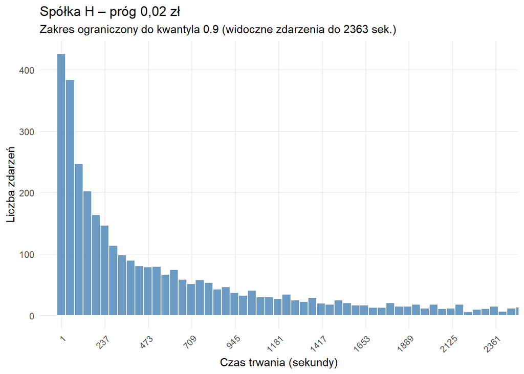

```r
plot_dynamic_duration_hist(durations_H_p02, "Spółka H – próg 0,02 zł")
```

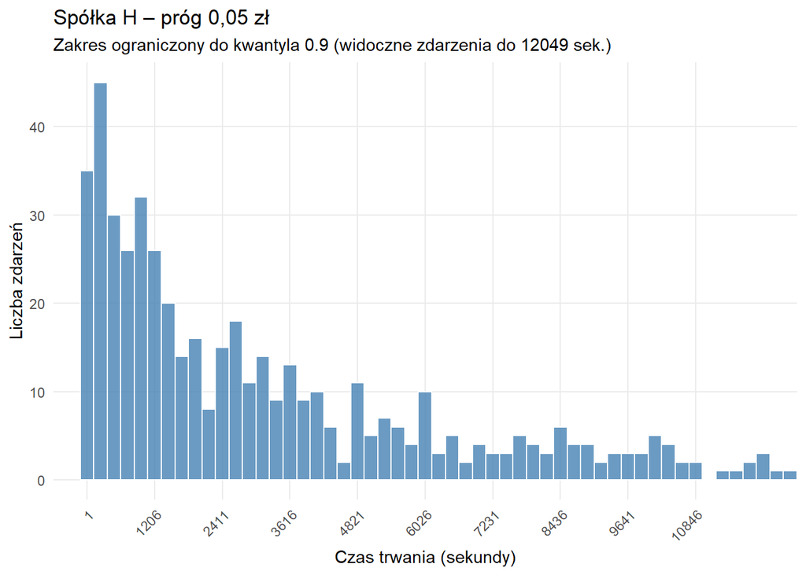

```r
plot_dynamic_duration_hist(durations_H_p05, "Spółka H – próg 0,05 zł")
```

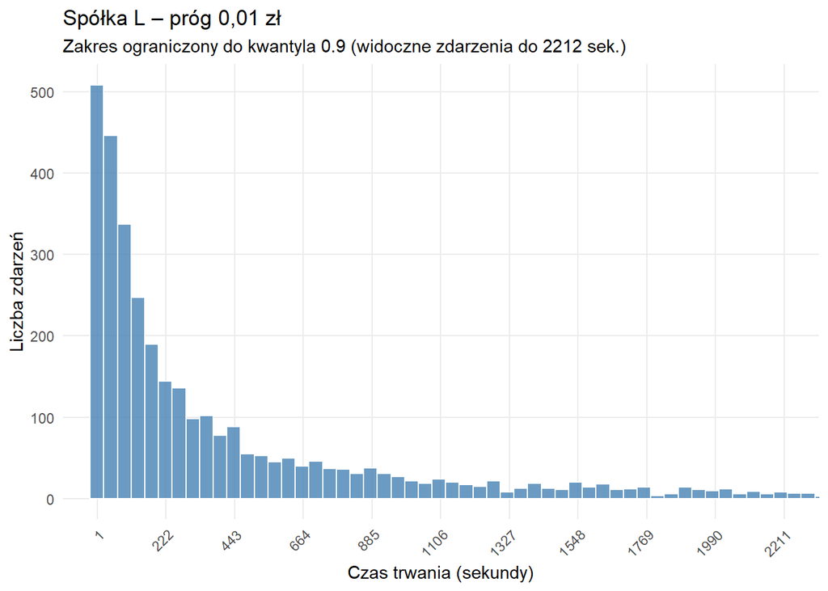

```r
plot_dynamic_duration_hist(durations_L_p01, "Spółka L – próg 0,01 zł")
```

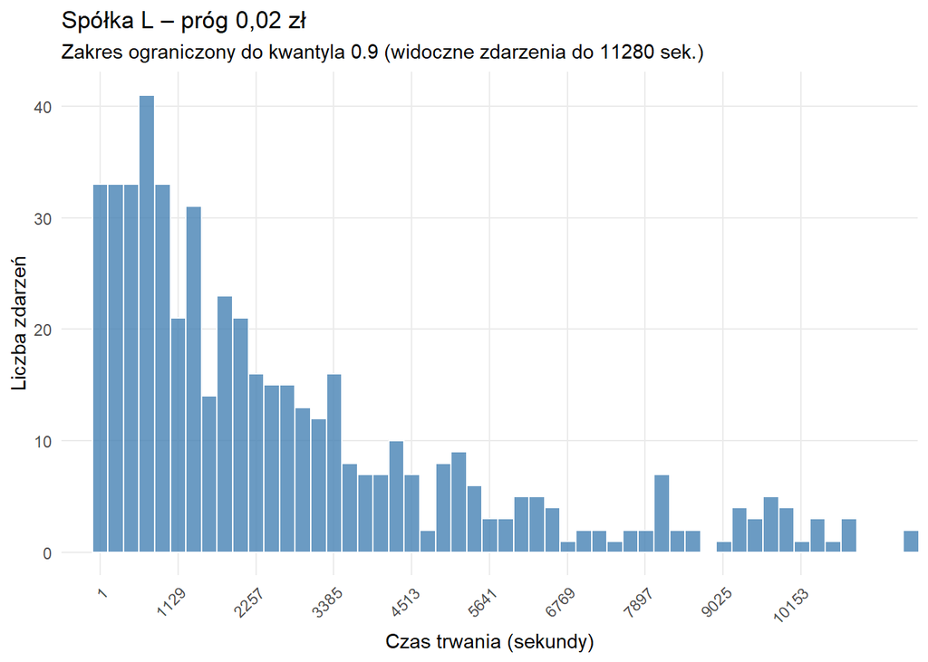

```r
plot_dynamic_duration_hist(durations_L_p02, "Spółka L – próg 0,02 zł")
```

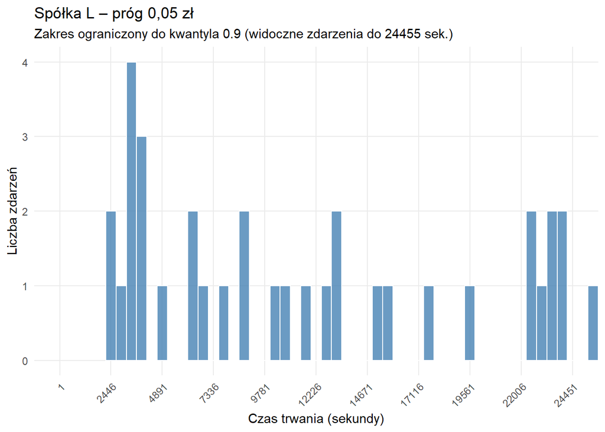

```r
plot_dynamic_duration_hist(durations_L_p05, "Spółka L – próg 0,05 zł")
```

Liczba obserwacji dla różnych wartości progu w czasach trwania ceny dla spółek H i L, a także analiza kształtu histogramów potwierdzają wcześniejsze obliczenia sugerowanych zakresów progów.

Dla Spółki H próg 0,01 zł generuje ogromną liczbę obserwacji (ponad 11 tysięcy). To sugeruje, że ta spółka “żyje” na poziomie pojedynczych groszy. świadczy to o jej płynności i gęstości arkusza zleceń. Przy 11 tys. obserwacji dla 1 grosza, histogram jest zdominowany przez mikroszum i transakcje o czasie 1 sekundy. Próg 0,05 zł to dobry kompromis: 654 obserwacje wystarczają do obliczenia statystyk, ale odcinają szum i pokazują realne ruchy ceny.

Spółka L przy progu 5 groszy ma tylko 161 obserwacji. To za mało, żeby budować zaawansowane modele (np. ACD), bo po podziale na dni wyjdzie zaledwie kilka zdarzeń na sesję. W tym przypadku Próg 0,02 zł to złoty środek: 679 obserwacji wystarczy do obliczenia statystyk, a zarazem odcina szum i pokazuje realne ruchy ceny. Przy tym unikamy rozkładu składającego się z dziur, jak przy progu 5 gr.

Do dalszych obliczeń oraz realizacji pozostałych poleceń wybierzemy wspólny dla obu spółek próg 0,02 zł. Dla spółki L jest to dobry wybór z powodów wymienionych w poprzednim akapicie, zaś dla spółki H jest wystarczająco dobry, bo nie generuje aż tak dużej liczby obserwacji jak próg 0,01 zł, bo tylko 3678. Unikamy przy tym szumu związanego z jednogroszowym progiem.

## 2.3. Statystyki opisowe wspólnego progu

```r
# Funkcja obliczająca statystyki opisowe
get_price_duration_stats <- function(data, company_name, threshold) {
  data.frame(
    Spółka = company_name,
    `Próg (zł)` = threshold,
    Średnia = mean(data$duration, na.rm = TRUE),
    Mediana = median(data$duration, na.rm = TRUE),
    `Odch stand.` = sd(data$duration, na.rm = TRUE),
    `Wsp zmienności` = as.numeric(sd(data$duration, na.rm = TRUE)/mean(data$duration, na.rm = TRUE)),
    Minimum = min(data$duration, na.rm = TRUE),
    Maksimum = max(data$duration, na.rm = TRUE),
    Skośność = skewness(data$duration, na.rm = TRUE),
    Kurtoza = kurtosis(data$duration, na.rm = TRUE),
    `Liczba obserwacji` = nrow(data)
  )
}

# Obliczenie statystyk dla progu 0,01 zł
stats_H_p02 <- get_price_duration_stats(durations_H_p02, "Spółka H", 0.02)
stats_L_p02 <- get_price_duration_stats(durations_L_p02, "Spółka L", 0.02)

# Połączenie wyników
stats_table_p02 <- bind_rows(stats_H_p02, stats_L_p02)

# Formatowanie tabeli
stats_table_p02_formatted <- stats_table_p02 %>%
  mutate(across(where(is.numeric), ~ round(., 2)))

knitr::kable(stats_table_p02_formatted, caption = "Statystyki opisowe cenowych czasów trwania dla progu 0,02 zł", digits = 2)
```

Statystyki opisowe cenowych czasów trwania dla progu 0,02 zł

| Spółka | Próg..zł. | Średnia | Mediana | Odch.stand. | Wsp.zmienności | Minimum | Maksimum | Skośność | Kurtoza | Liczba.obserwacji |
| --- | --- | --- | --- | --- | --- | --- | --- | --- | --- | --- |
| Spółka H | 0.02 | 925.35 | 351.0 | 1638.84 | 1.77 | 1 | 18390 | 4.31 | 26.24 | 3555 |
| Spółka L | 0.02 | 4118.21 | 2048.5 | 5229.55 | 1.27 | 1 | 28189 | 2.06 | 4.07 | 556 |

Analiza statystyk opisowych cenowych czasów trwania (price durations) dla spółek H i L przy progu zmiany ceny o 0,02 zł pozwala na wyciągnięcie istotnych wniosków dotyczących dynamiki handlu i płynności obu walorów:

1. Częstotliwość i płynność (liczba obserwacji)
- Spółka H (3555 obserwacji) generuje znacznie więcej zdarzeń cenowych niż Spółka L (556 obserwacji) w tym samym badanym okresie.
- Wniosek: Spółka H charakteryzuje się znacznie wyższą dynamiką zmian cen. Próg 0,02 zł jest przekraczany ponad 6-krotnie częściej niż w przypadku spółki L, co sugeruje wyższą płynność i większą aktywność transakcyjną na arkuszu zleceń spółki H.
2. Średni czas oczekiwania (średnia i mediana)
- Spółka H: Średni czas potrzebny na zmianę ceny o 0,02 zł to ok. 925 jednostek czasu, przy czym mediana jest znacznie niższa (351).
- Spółka L: Średni czas jest ponad 4-krotnie dłuższy (4118), a mediana wynosi 2048.
- Wniosek: W spółce L cena „stoi w miejscu” znacznie dłużej. Co ważne, w obu przypadkach średnia jest dużo wyższa od mediany, co jest typowe dla rozkładów czasów trwania i wskazuje na asymetrię prawostronną (występowanie nielicznych, ale bardzo długich okresów bez zmian ceny).
3. Zmienność i rozproszenie
- Współczynnik zmienności: Jest wyższy dla spółki H (1,77) niż dla L (1,27).
- Wniosek: Mimo że spółka H reaguje szybciej, jej czasy trwania są mniej stabilne (relatywnie bardziej rozproszone wokół średniej). Wartości większe od 1 sugerują, że rozkłady nie są wykładnicze (co jest standardem w finansach) i wykazują cechy tzw. „nadmiernej zmienności” (overdispersion).
4. Charakterystyka rozkładu (skośność i kurtoza) To tutaj widać najbardziej radykalne różnice:
- Skośność: Dla spółki H wynosi 4,31 (bardzo silna asymetria prawostronna), dla spółki L 2,06 (umiarkowana).
- Kurtoza: W spółce H mamy do czynienia z ekstremalnie wysoką kurtozą (26,24), podczas gdy w spółce L jest ona relatywnie niska (4,07).
- Interpretacja:
  - Rozkład spółki H jest leptokurtyczny w stopniu ekstremalnym. Oznacza to bardzo silną koncentrację wokół krótkich czasów trwania (szybkie zmiany ceny jedna po drugiej), ale jednocześnie występowanie tzw. „grubych ogonów” – rzadkich, ale ekstremalnie długich przerw w aktywności cenowej (maksimum dla H to 18390).
  - Spółka L ma rozkład bardziej „płaski” i przewidywalny w porównaniu do H, choć jej maksymalny czas trwania jest wyższy (28189), co wynika z jej ogólnie niższej płynności.

## 2.4. Wykresy przekrojowych średnich dla dwóch progów

Wybraliśmy przedziały czasowe 5-minutowe oraz progi 0,01 zł i 0,02 zł. Nie braliśmy pod uwagę progu 0,05 zł, ponieważ jak widać było na histogramie spółki L, ten był poszarpany, bo liczba obserwacji była zbyt niska.

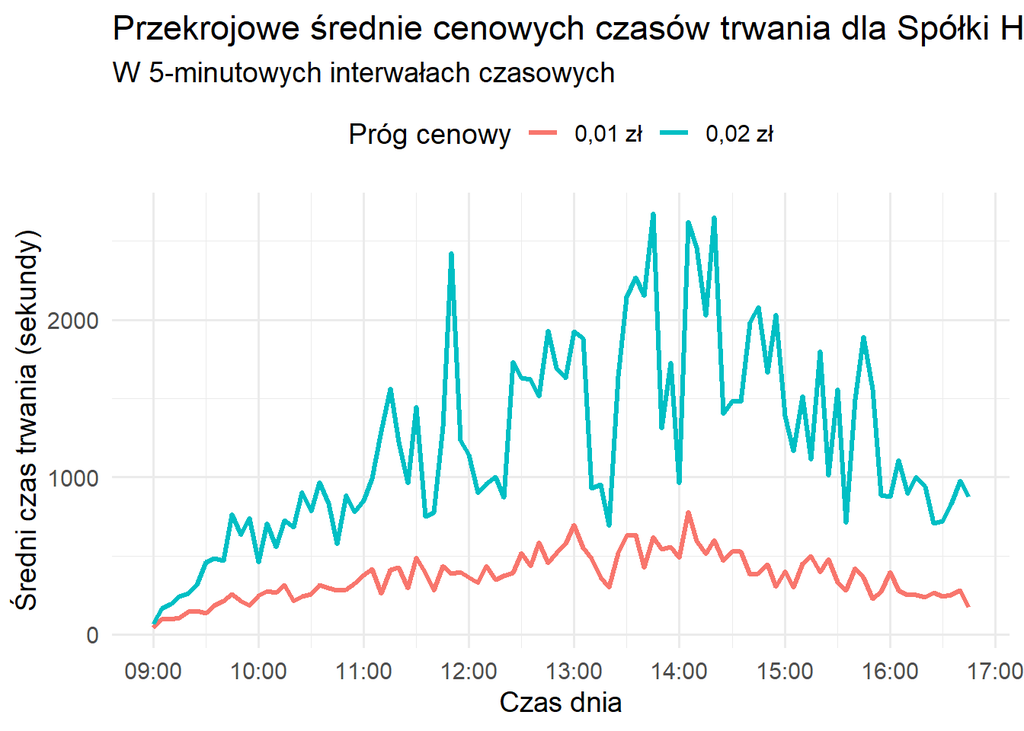

```r
# Funkcja obliczająca przekrojowe średnie w 5-minutowych interwałach
calculate_intraday_averages <- function(durations_df) {
  interval_averages <- durations_df %>%
    # 1. Tworzymy interwały 5-minutowe bezpośrednio z datetime
    mutate(
      interval = floor_date(datetime, "5 minutes"),
      # 2. Wyciągamy samą godzinę (HH:MM:SS), ignorując datę, aby móc liczyć średnią przekrojową (ze wszystkich dni)
      interval_time = hms::as_hms(format(interval, "%H:%M:%S"))
    ) %>%
    # 3. Grupujemy po porze dnia
    group_by(interval_time) %>%
    summarise(
      avg_duration = mean(duration, na.rm = TRUE),
      count = n(),
      .groups = "drop"
    ) %>%
    arrange(interval_time)

  return(interval_averages)
}

# Obliczenie średnich dla obu spółek i progów
# Spółka H
intraday_H_p01 <- calculate_intraday_averages(durations_H_p01)
intraday_H_p01$threshold <- "0,01 zł"
intraday_H_p01$company <- "Spółka H"

intraday_H_p02 <- calculate_intraday_averages(durations_H_p02)
intraday_H_p02$threshold <- "0,02 zł"
intraday_H_p02$company <- "Spółka H"

# Spółka L
intraday_L_p01 <- calculate_intraday_averages(durations_L_p01)
intraday_L_p01$threshold <- "0,01 zł"
intraday_L_p01$company <- "Spółka L"

intraday_L_p02 <- calculate_intraday_averages(durations_L_p02)
intraday_L_p02$threshold <- "0,02 zł"
intraday_L_p02$company <- "Spółka L"

# Wykres dla Spółki H
ggplot_H <- ggplot(bind_rows(intraday_H_p01, intraday_H_p02),
                  aes(x = interval_time, y = avg_duration, color = threshold)) +
  geom_line(size = 1.2) +
  scale_x_time(breaks = scales::breaks_width("1 hour"),
               labels = scales::label_time(format = "%H:%M")) +
  labs(
    title = "Przekrojowe średnie cenowych czasów trwania dla Spółki H",
    subtitle = "W 5-minutowych interwałach czasowych",
    x = "Czas dnia",
    y = "Średni czas trwania (sekundy)",
    color = "Próg cenowy"
  ) +
  theme_minimal(base_size = 14) +
  theme(legend.position = "top")

# Wykres dla Spółki L
ggplot_L <- ggplot(bind_rows(intraday_L_p01, intraday_L_p02),
                  aes(x = interval_time, y = avg_duration, color = threshold)) +
  geom_line(size = 1.2) +
  scale_x_time(breaks = scales::breaks_width("1 hour"),
               labels = scales::label_time(format = "%H:%M")) +
  labs(
    title = "Przekrojowe średnie cenowych czasów trwania dla Spółki L",
    subtitle = "W 5-minutowych interwałach czasowych",
    x = "Czas dnia",
    y = "Średni czas trwania (sekundy)",
    color = "Próg cenowy"
  ) +
  theme_minimal(base_size = 14) +
  theme(legend.position = "top")

# Wyświetlenie obu wykresów
ggplot_H
```

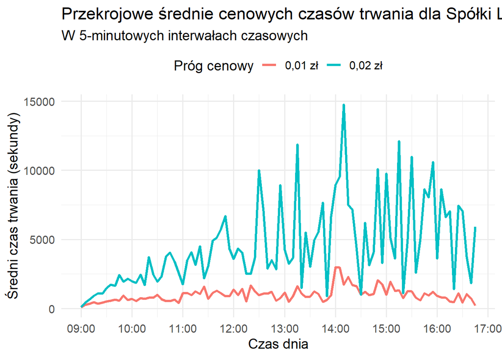

```r
ggplot_L
```

Te dwa wykresy dają świetny wgląd w to, jak płynność spółki wpływa na tzw. cenowe czasy trwania (price durations). O ile poprzednio analizowaliśmy czasy między transakcjami, tutaj patrzymy na czas, jaki musi upłynąć, aby cena zmieniła się o określoną wartość (0,01 zł lub 0,02 zł).

1. Skala i płynność

To pierwszy element, który rzuca się w oczy i definiuje obie spółki:

- Spółka H: Oś Y kończy się na ok. 2500–3000 sekund. Zmiana ceny o 2 grosze zajmuje tu średnio od 15 do 40 minut w ciągu dnia.
- Spółka L: Oś Y sięga aż 15 000 sekund. Oznacza to, że w okresach mniejszej płynności (środek dnia), na zmianę ceny o 0,02 zł trzeba czekać nawet 4 godziny.
- Wniosek: Spółka L jest drastycznie mniej płynna. Cena zatrzymuje się na jednym poziomie na znacznie dłużej niż w przypadku spółki H.
2. Wpływ progu cenowego (0,01 zł, a 0,02 zł)

Na obu wykresach widać, że zależność między progiem a czasem trwania nie jest liniowa:

- Nieliniowy skok: Podwojenie progu (z 1 gr na 2 gr) powoduje znacznie więcej niż podwojenie czasu oczekiwania. Widać to szczególnie u Spółki L, gdzie linia niebieska (0,02 zł) “odlatuje” od czerwonej, tworząc ogromne piki.
- Stabilność 1 gr: Dla progu 0,01 zł obie spółki zachowują się relatywnie stabilnie (w swoich skalach). Sugeruje to, że mniejsze zmiany ceny są realizowane w miarę płynnie przez mniejsze zlecenia.
3. Sezonowość śróddzienna

Oba wykresy potwierdzają klasyczny wzorzec aktywności rynkowej:

Zgodnie z wykładem:

“Przed przystąpieniem do modelowania czasów trwania konieczne jest wcześniejsze usunięcie efektu śróddziennej cykliczności.”

### 2.4.1. Przygotowanie danych

```r
prepare_data <- function(df){
  df %>%
    filter(duration > 0) %>%
    transmute(
      durations = duration,
      time = as.POSIXct(datetime)
    )%>%
    group_by(time) %>%
    summarise(durations = sum(durations), .groups = "drop")
}

# Selekcja danych dla minimalnego progu (0,01 zł)
# Spółka H
durations_H_min <- durations_H_p01 %>%
  mutate(datetime = as.POSIXct(datetime))

# Spółka L
durations_L_min <- durations_L_p01 %>%
  mutate(datetime = as.POSIXct(datetime))

# Przygotowanie danych
durH_pre <- prepare_data(durations_H_min)
durL_pre <- prepare_data(durations_L_min)

# Usunięcie śróddziennej sezonowości
remove_season1 <- function(df) {
  adj <- diurnalAdj(
    dur = df,
    method = "FFF",
    aggregation = "weekdays",
    Q = 3
  )
  df <- df %>%
    mutate(
      adjDur = adj$adjDur,
      seasonal = durations / adj$adjDur,
      weekday = wday(time, label = TRUE)
    )
  return(df)
}

# Usunięcie sezonowości dla obu spółek
daneH_adj_c <- remove_season1(daneH_pre)
```

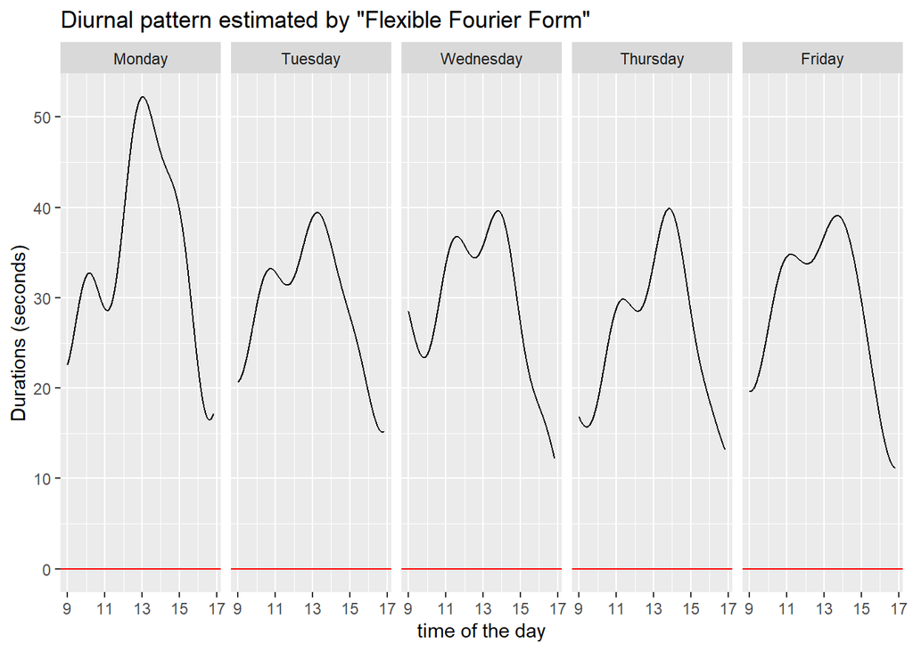

```r
daneL_adj_c <- remove_season1(daneL_pre)
```

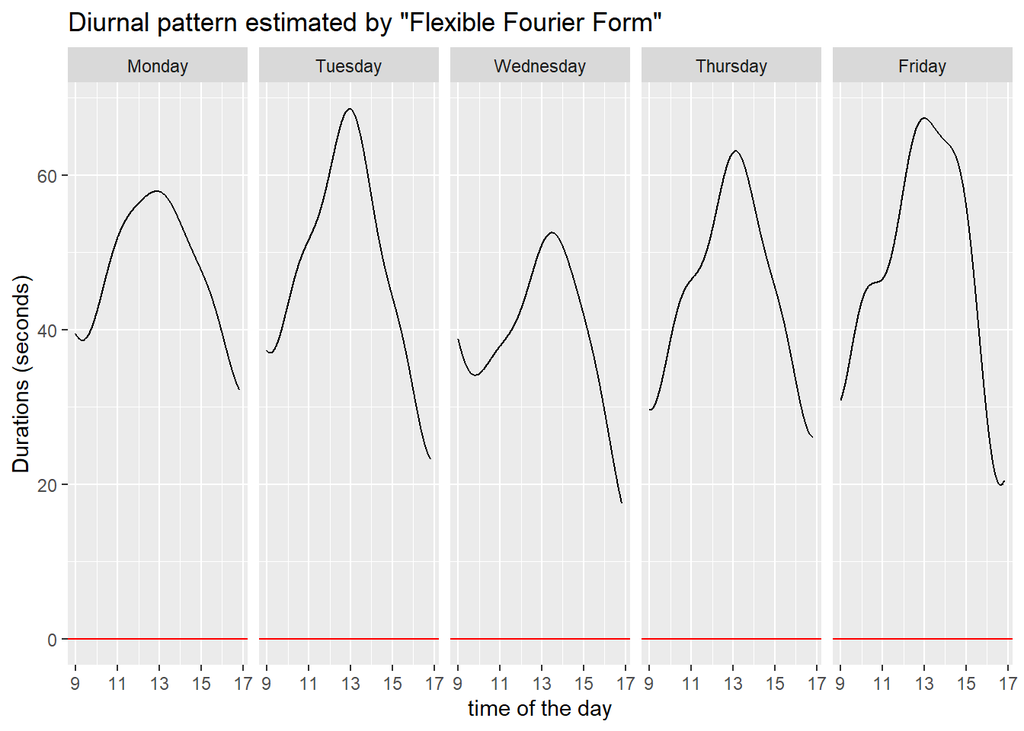

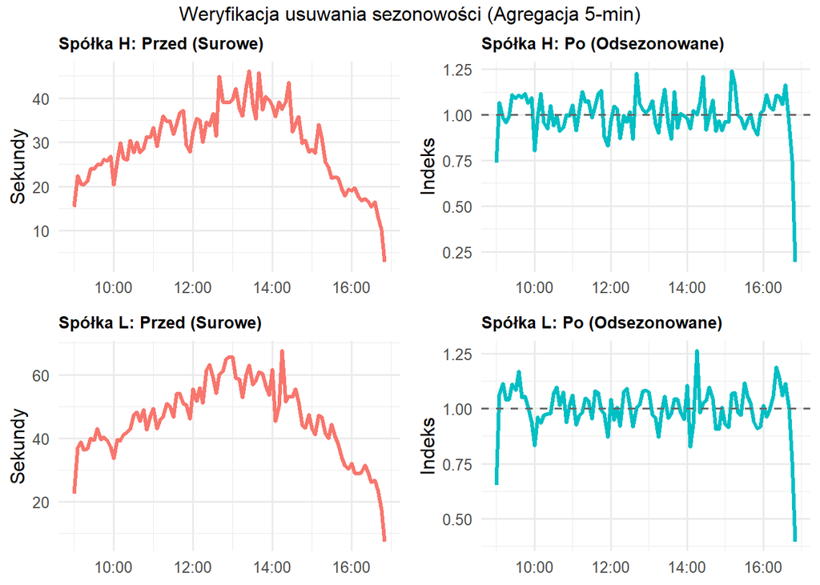

```r
get_seasonality_averages <- function(df) {

  # A. Tworzenie 5-minutowych interwałów (zachowuje datę)
  df$interval <- floor_date(df$time, "5 minutes")

  # B. KLUCZOWE: Ekstrakcja samego czasu (spłaszcza dni do jednej doby)
  df$interval_time <- hms::as_hms(df$interval)

  # C. Obliczenie średnich dla obu typów danych (surowe i odsezonowane)
  interval_avgs <- df %>%
    group_by(interval_time) %>%
    summarise(
      avg_raw = mean(durations, na.rm = TRUE),    # Dane przed (surowe)
      avg_adj = mean(adjDur, na.rm = TRUE),     # Dane po (odsezonowane)
      count = n()
    ) %>%
    ungroup()

  return(interval_avgs)
}

plot_data_H <- get_seasonality_averages(daneH_adj_c)
plot_data_L <- get_seasonality_averages(daneL_adj_c)

make_plot <- function(data, y_col, title_text, y_lab, color_hex, add_ref_line = FALSE) {

  p <- ggplot(data, aes(x = interval_time, y = .data[[y_col]])) +
    geom_line(size = 1.2, color = color_hex) +
    scale_x_time(breaks = scales::breaks_width("2 hours"),
                 labels = scales::label_time(format = "%H:%M")) +
    labs(
      title = title_text,
      x = NULL, # Usuwam 'Czas dnia' żeby nie dublować w siatce
      y = y_lab
    ) +
    theme_minimal(base_size = 12) +
    theme(plot.title = element_text(size = 10, face = "bold"))

  if(add_ref_line) {
    p <- p + geom_hline(yintercept = 1, linetype = "dashed", color = "gray40")
  }

  return(p)
}

#Spółka H
p1_H_raw <- make_plot(plot_data_H, "avg_raw", "Spółka H: Przed (Surowe)", "Sekundy", "#F8766D", FALSE)
p2_H_adj <- make_plot(plot_data_H, "avg_adj", "Spółka H: Po (Odsezonowane)", "Indeks", "#00BFC4", TRUE)

#Spółka L
p3_L_raw <- make_plot(plot_data_L, "avg_raw", "Spółka L: Przed (Surowe)", "Sekundy", "#F8766D", FALSE)
p4_L_adj <- make_plot(plot_data_L, "avg_adj", "Spółka L: Po (Odsezonowane)", "Indeks", "#00BFC4", TRUE)


grid.arrange(
  p1_H_raw, p2_H_adj,
  p3_L_raw, p4_L_adj,
  ncol = 2,
  top = "Weryfikacja usuwania sezonowości (Agregacja 5-min)"
)
```

*Wnioski:*

Spółka H:

Spółka L:

Patrząc na przedstawione zestawienie 4 wykresów (szczególnie na wykresy weryfikacyjne), można jednoznacznie stwierdzić, że zabieg usunięcia sezonowości śróddziennej zakończył się sukcesem:

1. Eliminacja wzorca „odwróconego U”
- Przed korektą: Wykresy surowe dla obu spółek wykazują klasyczny, wypukły kształt – czasy trwania są najkrótsze na otwarciu i zamknięciu, a najdłuższe w środku dnia (tzw. efekt lunchu).
- Po korekcie: Wyraźny „garb” całkowicie zniknął. Zastąpił go proces oscylujący wokół stałego poziomu, co jest kluczowe dla dalszego modelowania statystycznego.
2. Stabilizacja średniej (Indeks $\approx 1.0$)
- Na wykresach odsezonowanych oś Y nie pokazuje już sekund, lecz indeks (adjusted duration).
- Wartości oscylują stabilnie wokół poziomu 1.0 przez niemal całą sesję. Oznacza to, że model poprawnie „wyłapał” lokalną normę czasową dla każdej godziny i sprowadził dane do wspólnego mianownika.
3. Charakterystyka sygnału
- Dane po korekcie przypominają teraz biały szum.
- Dzięki temu zabiegowi, ewentualne piki (odchylenia powyżej lub poniżej 1.0) nie wynikają już z pory dnia, ale z rzeczywistych, nietypowych zdarzeń rynkowych lub napływu istotnych informacji.

### 2.4.2. Dopasowanie modeli ACD/LACD (1, 1) oraz (2, 2)

Po usunięciu śróddziennej sezonowości możemy przystąpić do modelowania ACD/LACD dla obu spółek. Przeanalizowane zostaną modele ACD, LACD1, LACD2 oraz z rozkładami: Burra, Weibulla, Gamma, a następnie wybrana najlepsza kombinacja tych parametrów. Rozważane modele będą miały parametry p i q równe 1, a mastępnie sprawdzimy te dla p=q=2.

```r
# Przygotowanie danych dla modelowania ACD/LACD
# Z założeń zadania, dane są już w daneH_adj i daneL_adj po usunięciu cykliczności

# Przygotowanie danych - tworzenie wektorów czasów trwania
durations_H <- daneH_adj_c$adjDur
durations_L <- daneL_adj_c$adjDur

# Usunięcie ewentualnych NA i wartości nie dodatnich
durations_H <- na.omit(durations_H[durations_H > 0])
durations_L <- na.omit(durations_L[durations_L > 0])

# Funkcja dopasowująca wszystkie modele ACD/LACD z różnymi rozkładami
fit_all_acd_models <- function(durations, company_name, p=1, q=1) {
  cat("\n=== DOPASOWANIE MODELI ACD/LACD (", p, ", ", q, ") DLA", company_name, "===\n")

  # Lista do przechowywania modeli
  models <- list()
  results <- data.frame(Model = character(), AIC = numeric(), LogLik = numeric(),
                       n_params = numeric(), stringsAsFactors = FALSE)

  # 1. Modele ACD(1,1)

  ## ACD(1,1) z rozkładem Weibulla
  tryCatch({
    model <- acdFit(
      durations = durations,
      model = "ACD",
      dist = "weibull",
      order = c(p, q),
      output = FALSE
    )
    models[["ACD_Weibull"]] <- model
    results <- rbind(results, data.frame(
      Model = "ACD_Weibull",
      AIC = model$goodnessOfFit$value[2],
      LogLik = model$goodnessOfFit$value[1],
      n_params = model$Npar
    ))
    cat("Model ACD_Weibull dopasowany\n")
  }, error = function(e) cat("Błąd w modelu ACD_Weibull:", e$message, "\n"))

  ## ACD(1,1) z rozkładem Burra
  tryCatch({
    model <- acdFit(
      durations = durations,
      model = "ACD",
      dist = "burr",
      order = c(p, q),
      output = FALSE
    )
    models[["ACD_Burr"]] <- model
    results <- rbind(results, data.frame(
      Model = "ACD_Burr",
      AIC = model$goodnessOfFit$value[2],
      LogLik = model$goodnessOfFit$value[1],
      n_params = model$Npar
    ))
    cat("Model ACD_Burr dopasowany\n")
  }, error = function(e) cat("Błąd w modelu ACD_Burr:", e$message, "\n"))

  ## ACD(1,1) z uogólnionym rozkładem Gamma
  tryCatch({
    model <- acdFit(
      durations = durations,
      model = "ACD",
      dist = "gengamma",
      order = c(p, q),
      output = FALSE
    )
    models[["ACD_GenGamma"]] <- model
    results <- rbind(results, data.frame(
      Model = "ACD_GenGamma",
      AIC = model$goodnessOfFit$value[2],
      LogLik = model$goodnessOfFit$value[1],
      n_params = model$Npar
    ))
    cat("Model ACD_GenGamma dopasowany\n")
  }, error = function(e) cat("Błąd w modelu ACD_GenGamma:", e$message, "\n"))

  # 2. Modele LACD1(1,1)

  ## LACD1(1,1) z rozkładem Weibulla
  tryCatch({
    model <- acdFit(
      durations = durations,
      model = "LACD1",
      dist = "weibull",
      order = c(p, q),
      output = FALSE
    )
    models[["LACD1_Weibull"]] <- model
    results <- rbind(results, data.frame(
      Model = "LACD1_Weibull",
      AIC = model$goodnessOfFit$value[2],
      LogLik = model$goodnessOfFit$value[1],
      n_params = model$Npar
    ))
    cat("Model LACD1_Weibull dopasowany\n")
  }, error = function(e) cat("Błąd w modelu LACD1_Weibull:", e$message, "\n"))

  ## LACD1(1,1) z rozkładem Burra
  tryCatch({
    model <- acdFit(
      durations = durations,
      model = "LACD1",
      dist = "burr",
      order = c(p, q),
      output = FALSE
    )
    models[["LACD1_Burr"]] <- model
    results <- rbind(results, data.frame(
      Model = "LACD1_Burr",
      AIC = model$goodnessOfFit$value[2],
      LogLik = model$goodnessOfFit$value[1],
      n_params = model$Npar
    ))
    cat("Model LACD1_Burr dopasowany\n")
  }, error = function(e) cat("Błąd w modelu LACD1_Burr:", e$message, "\n"))

  ## LACD1(1,1) z uogólnionym rozkładem Gamma
  tryCatch({
    model <- acdFit(
      durations = durations,
      model = "LACD1",
      dist = "gengamma",
      order = c(p, q),
      output = FALSE
    )
    models[["LACD1_GenGamma"]] <- model
    results <- rbind(results, data.frame(
      Model = "LACD1_GenGamma",
      AIC = model$goodnessOfFit$value[2],
      LogLik = model$goodnessOfFit$value[1],
      n_params = model$Npar
    ))
    cat("Model LACD1_GenGamma dopasowany\n")
  }, error = function(e) cat("Błąd w modelu LACD1_GenGamma:", e$message, "\n"))

  # 3. Modele LACD2(1,1)

  ## LACD2(1,1) z rozkładem Weibulla
  tryCatch({
    model <- acdFit(
      durations = durations,
      model = "LACD2",
      dist = "weibull",
      order = c(p, q),
      output = FALSE
    )
    models[["LACD2_Weibull"]] <- model
    results <- rbind(results, data.frame(
      Model = "LACD2_Weibull",
      AIC = model$goodnessOfFit$value[2],
      LogLik = model$goodnessOfFit$value[1],
      n_params = model$Npar
    ))
    cat("Model LACD2_Weibull dopasowany\n")
  }, error = function(e) cat("Błąd w modelu LACD2_Weibull:", e$message, "\n"))

  ## LACD2(1,1) z rozkładem Burra
  tryCatch({
    model <- acdFit(
      durations = durations,
      model = "LACD2",
      dist = "burr",
      order = c(p, q),
      output = FALSE
    )
    models[["LACD2_Burr"]] <- model
    results <- rbind(results, data.frame(
      Model = "LACD2_Burr",
      AIC = model$goodnessOfFit$value[2],
      LogLik = model$goodnessOfFit$value[1],
      n_params = model$Npar
    ))
    cat("Model LACD2_Burr dopasowany\n")
  }, error = function(e) cat("Błąd w modelu LACD2_Burr:", e$message, "\n"))

  ## LACD2(1,1) z uogólnionym rozkładem Gamma
  tryCatch({
    model <- acdFit(
      durations = durations,
      model = "LACD2",
      dist = "gengamma",
      order = c(p, q),
      output = FALSE
    )
    models[["LACD2_GenGamma"]] <- model
    results <- rbind(results, data.frame(
      Model = "LACD2_GenGamma",
      AIC = model$goodnessOfFit$value[2],
      LogLik = model$goodnessOfFit$value[1],
      n_params = model$Npar
    ))
    cat("Model LACD2_GenGamma dopasowany\n")
  }, error = function(e) cat("✗ Błąd w modelu LACD2_GenGamma:", e$message, "\n"))

  # Sortowanie wyników według AIC
  results <- results %>% arrange(AIC)

  cat("\nWyniki modeli uporządkowane według kryterium AIC:\n")
  print(results, digits = 3)

  # Wybór najlepszego modelu
  best_model_name <- results$Model[1]
  best_model <- models[[best_model_name]]

  cat("\n Najlepszy model według AIC:", best_model_name, "\n")
  cat("Parametry modelu:\n")
  print(coef(best_model), digits = 4)

  return(list(
    all_models = models,
    results = results,
    best_model = best_model,
    best_model_name = best_model_name
  ))
}

# Dopasowanie modeli dla obu spółek
results_H_1_1 <- fit_all_acd_models(durations_H, "SPÓŁKI H",p=1,q=1)
```

```
##
## === DOPASOWANIE MODELI ACD/LACD ( 1 ,  1 ) DLA SPÓŁKI H ===
## Model ACD_Weibull dopasowany
## Model ACD_Burr dopasowany
## Model ACD_GenGamma dopasowany
## Model LACD1_Weibull dopasowany
## Model LACD1_Burr dopasowany
## Model LACD1_GenGamma dopasowany
## Model LACD2_Weibull dopasowany
## Model LACD2_Burr dopasowany
## Model LACD2_GenGamma dopasowany
##
## Wyniki modeli uporządkowane według kryterium AIC:
##            Model    AIC LogLik n_params
## 1 LACD1_GenGamma 176369 -88179        5
## 2   ACD_GenGamma 178579 -89284        5
## 3 LACD2_GenGamma 180075 -90033        5
## 4     LACD1_Burr 181675 -90832        5
## 5       ACD_Burr 183078 -91534        5
## 6     LACD2_Burr 185223 -92606        5
## 7    ACD_Weibull 189446 -94719        4
## 8  LACD2_Weibull 189938 -94965        4
## 9  LACD1_Weibull 191956 -95974        4
##
##  Najlepszy model według AIC: LACD1_GenGamma
## Parametry modelu:
##     omega    alpha1     beta1     kappa     gamma
##   0.13062   0.13561   0.95310 815.88919   0.02464
```

```r
results_L_1_1 <- fit_all_acd_models(durations_L, "SPÓŁKI L",p=1,q=1)
```

```
##
## === DOPASOWANIE MODELI ACD/LACD ( 1 ,  1 ) DLA SPÓŁKI L ===
## Model ACD_Weibull dopasowany
## Model ACD_Burr dopasowany
## Model ACD_GenGamma dopasowany
## Model LACD1_Weibull dopasowany
## Model LACD1_Burr dopasowany
## Model LACD1_GenGamma dopasowany
## Model LACD2_Weibull dopasowany
## Model LACD2_Burr dopasowany
## Model LACD2_GenGamma dopasowany
##
## Wyniki modeli uporządkowane według kryterium AIC:
##            Model    AIC LogLik n_params
## 1   ACD_GenGamma 122947 -61469        5
## 2 LACD2_GenGamma 122961 -61476        5
## 3       ACD_Burr 123510 -61750        5
## 4     LACD2_Burr 123513 -61752        5
## 5  LACD2_Weibull 123872 -61932        4
## 6 LACD1_GenGamma 123921 -61955        5
## 7    ACD_Weibull 123945 -61969        4
## 8     LACD1_Burr 124932 -62461        5
## 9  LACD1_Weibull 126351 -63171        4
##
##  Najlepszy model według AIC: ACD_GenGamma
## Parametry modelu:
##    omega   alpha1    beta1    kappa    gamma
## 0.006802 0.096961 0.899764 2.175069 0.525409
```

```r
results_H_2_2 <- fit_all_acd_models(durations_H, "SPÓŁKI H",p=2,q=2)
```

```
##
## === DOPASOWANIE MODELI ACD/LACD ( 2 ,  2 ) DLA SPÓŁKI H ===
## non-finite finite-difference value [1]
##
## Error: Oops, seems like the the optimization function failed. Changing the 'optimFnc' or/and its settings, or starting from a diffrent 'startPara' might work. You can also trace the MLE search path by adding the argument 'control = list(trace = 1)'.
##
## Błąd w modelu ACD_Weibull: argumenty sugerują różną liczbę wierszy: 1, 0
## Model ACD_Burr dopasowany
## Model ACD_GenGamma dopasowany
## Model LACD1_Weibull dopasowany
## Model LACD1_Burr dopasowany
## Model LACD1_GenGamma dopasowany
## Model LACD2_Weibull dopasowany
## Model LACD2_Burr dopasowany
## Model LACD2_GenGamma dopasowany
##
## Wyniki modeli uporządkowane według kryterium AIC:
##            Model    AIC LogLik n_params
## 1   ACD_GenGamma 179651 -89819        7
## 2 LACD1_GenGamma 179876 -89931        7
## 3     LACD1_Burr 181200 -90593        7
## 4 LACD2_GenGamma 182440 -91213        7
## 5       ACD_Burr 182913 -91450        7
## 6     LACD2_Burr 184217 -92102        7
## 7  LACD2_Weibull 189675 -94831        6
## 8  LACD1_Weibull 190752 -95370        6
##
##  Najlepszy model według AIC: ACD_GenGamma
## Parametry modelu:
##    omega   alpha1   alpha2    beta1    beta2    kappa    gamma
##  0.07667  0.23029  0.22972 -0.24126  0.75587  6.97926  0.26646
```

```r
results_L_2_2 <- fit_all_acd_models(durations_L, "SPÓŁKI L",p=2,q=2)
```

```
##
## === DOPASOWANIE MODELI ACD/LACD ( 2 ,  2 ) DLA SPÓŁKI L ===
## Model ACD_Weibull dopasowany
## Model ACD_Burr dopasowany
## non-finite finite-difference value [1]
##
## Error: Oops, seems like the the optimization function failed. Changing the 'optimFnc' or/and its settings, or starting from a diffrent 'startPara' might work. You can also trace the MLE search path by adding the argument 'control = list(trace = 1)'.
##
## Błąd w modelu ACD_GenGamma: argumenty sugerują różną liczbę wierszy: 1, 0
## non-finite finite-difference value [2]
##
## Error: Oops, seems like the the optimization function failed. Changing the 'optimFnc' or/and its settings, or starting from a diffrent 'startPara' might work. You can also trace the MLE search path by adding the argument 'control = list(trace = 1)'.
##
## Błąd w modelu LACD1_Weibull: argumenty sugerują różną liczbę wierszy: 1, 0
## Model LACD1_Burr dopasowany
## Model LACD1_GenGamma dopasowany
## Model LACD2_Weibull dopasowany
## Model LACD2_Burr dopasowany
## Model LACD2_GenGamma dopasowany
##
## Wyniki modeli uporządkowane według kryterium AIC:
##            Model    AIC LogLik n_params
## 1 LACD2_GenGamma 122918 -61452        7
## 2     LACD2_Burr 123484 -61735        7
## 3       ACD_Burr 123500 -61743        7
## 4  LACD2_Weibull 123853 -61921        6
## 5 LACD1_GenGamma 123880 -61933        7
## 6    ACD_Weibull 123902 -61945        6
## 7     LACD1_Burr 124832 -62409        7
##
##  Najlepszy model według AIC: LACD2_GenGamma
## Parametry modelu:
##    omega   alpha1   alpha2    beta1    beta2    kappa    gamma
## -0.09211  0.09987 -0.01020  0.80836  0.17712  1.95329  0.55889
```

1. Analiza modeli z parametrami (1, 1)

W tej klasie parametrów testowano modele ACD, LACD1 oraz LACD2 z różnymi rozkładami składnika losowego.

- Spółka H:
  - Najlepszy model: LACD1_GenGamma ($AIC = 176369$).
  - Zwycięski rozkład: Uogólniony rozkład Gamma (GenGamma) okazał się bezkonkurencyjny, zajmując pierwsze trzy miejsca w rankingu AIC dla wszystkich typów modeli (LACD1, ACD, LACD2).
  - Parametry: Model wykazuje bardzo wysoką trwałość (persistence), gdzie $\beta_1 = 0.9531$. Parametr $\alpha_1$ na poziomie $0.1356$ wskazuje na istotną reakcję na ostatnią zaobserwowaną zmianę ceny.
- Spółka L:
  - Najlepszy model: ACD_GenGamma ($AIC = 122947$).
  - Charakterystyka: Model LACD2_GenGamma uzyskał niemal identyczny wynik AIC ($122961$), co sugeruje, że dla spółki L struktura logarytmiczna i standardowa ACD dają zbliżone rezultaty.
2. Analiza modeli z parametrami (2, 2)

Zwiększenie rzędu opóźnień miało na celu sprawdzenie, czy uwzględnienie głębszej historii czasów trwania poprawi zdolność predykcyjną modeli.

## 2.5. Diagnostyka modeli (1, 1) oraz (2, 2)

### 2.5.1. Diagnostyka modeli (1, 1)

```
##
## === DIAGNOSTYKA DLA MODELU LACD1_GenGamma ( SPÓŁKI H ) ===
##
## Test Andersona-Darlinga dla standaryzowanych reszt (PIT):
## Statystyka testowa: 155.9841
## Wartość p: 0
## Test odrzuca hipotezę zerową - rozkład nie jest jednostajny
##
## Test Ljunga-Boxa dla reszt:
## Statystyka: 2624.735 Wartość p: 0
## Istotna autokorelacja w resztach
##
## Test Ljunga-Boxa dla kwadratów reszt:
## Statystyka: 602.7312 Wartość p: 0
## Istotna autokorelacja w kwadratach reszt
```

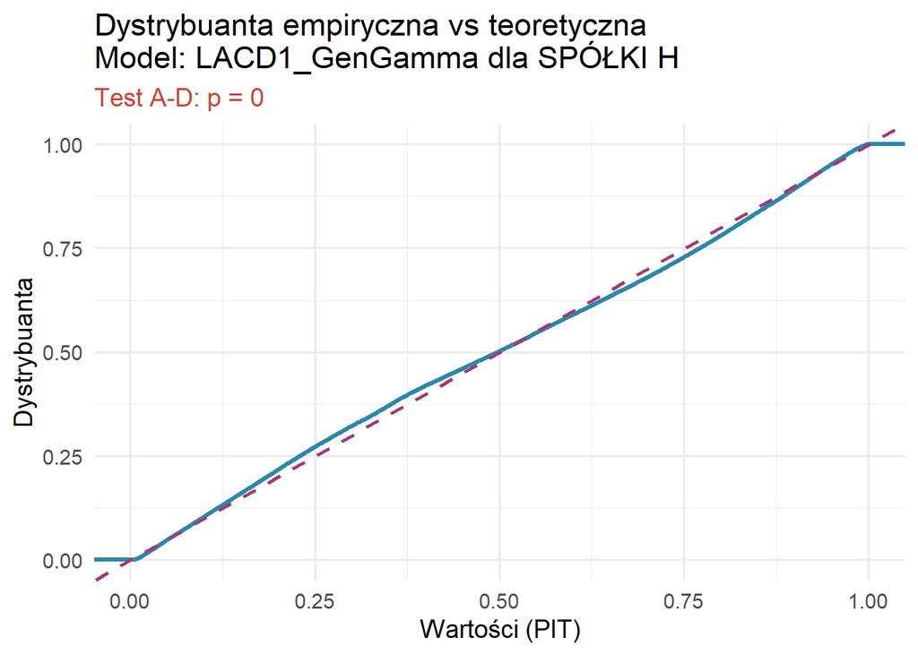

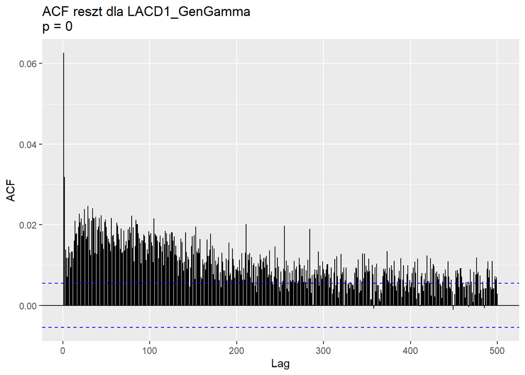

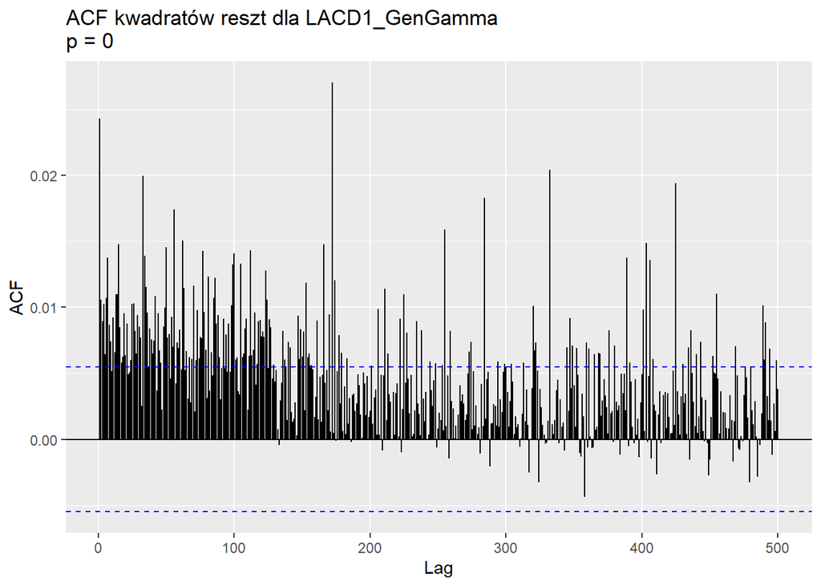

```r
# Funkcja diagnostyczna dla wybranego modelu
model_diagnostics <- function(model, model_name, company_name) {
  cat("\n=== DIAGNOSTYKA DLA MODELU", model_name, "(", company_name, ") ===\n")

  # 1. Standaryzacja reszt z transformacją PIT
  std_resids <- standardizeResi(model, transformation = "probIntegral")

  # 2. Test Andersona-Darlinga dla jednostajności
  ad_test <- ad.test(std_resids, null = "punif")
  cat("\nTest Andersona-Darlinga dla standaryzowanych reszt (PIT):\n")
  cat("Statystyka testowa:", round(ad_test$statistic, 4), "\n")
  cat("Wartość p:", round(ad_test$p.value, 4), "\n")
  if (ad_test$p.value > 0.05) {
    cat("Test nie odrzuca hipotezy zerowej - rozkład jest jednostajny\n")
  } else {
    cat("Test odrzuca hipotezę zerową - rozkład nie jest jednostajny\n")
  }

  # 3. Testy autokorelacji
  residuals <- residuals(model)
  squared_residuals <- residuals^2

  lb_test <- Box.test(residuals, lag = 50, type = "Ljung-Box")
  lb_test_sq <- Box.test(squared_residuals, lag = 50, type = "Ljung-Box")

  cat("\nTest Ljunga-Boxa dla reszt:\n")
  cat("Statystyka:", round(lb_test$statistic, 4),
      "Wartość p:", round(lb_test$p.value, 4), "\n")
  if (lb_test$p.value > 0.05) {
    cat("Brak istotnej autokorelacji w resztach\n")
  } else {
    cat("Istotna autokorelacja w resztach\n")
  }

  cat("\nTest Ljunga-Boxa dla kwadratów reszt:\n")
  cat("Statystyka:", round(lb_test_sq$statistic, 4),
      "Wartość p:", round(lb_test_sq$p.value, 4), "\n")
  if (lb_test_sq$p.value > 0.05) {
    cat("Brak istotnej autokorelacji w kwadratach reszt\n")
  } else {
    cat("Istotna autokorelacja w kwadratach reszt\n")
  }

  # 4. Wykres dystrybuanty empirycznej vs teoretycznej
  ecdf_data <- data.frame(x = std_resids)
  ecdf_plot <- ggplot(ecdf_data, aes(x = x)) +
    stat_ecdf(geom = "step", color = "#2E86AB", size = 1.2) +
    geom_abline(intercept = 0, slope = 1, color = "#A23B72", linetype = "dashed", size = 1) +
    labs(title = paste("Dystrybuanta empiryczna vs teoretyczna",
                      "\nModel:", model_name, "dla", company_name),
         subtitle = paste("Test A-D: p =", round(ad_test$p.value, 4)),
         x = "Wartości (PIT)", y = "Dystrybuanta") +
    theme_minimal(base_size = 14) +
    theme(plot.subtitle = element_text(color = ifelse(ad_test$p.value > 0.05, "#138D75", "#CB4335")))

  # 5. Wykres autokorelacji
  acf_plot <- ggAcf(residuals, lag.max = 500,
                   main = paste("ACF reszt dla", model_name,
                               "\np =", round(lb_test$p.value, 4)))
  acf_sq_plot <- ggAcf(squared_residuals, lag.max = 500,
                      main = paste("ACF kwadratów reszt dla", model_name,
                                  "\np =", round(lb_test_sq$p.value, 4)))

  # Wyświetlenie wykresów
  print(ecdf_plot)
  print(acf_plot)
  print(acf_sq_plot)

  return(list(
    ad_test = ad_test,
    lb_test = lb_test,
    lb_test_sq = lb_test_sq,
    standardized_residuals = std_resids
  ))
}

# Przeprowadzenie diagnostyki dla najlepszych modeli
diagnostics_H_1_1 <- model_diagnostics(results_H_1_1$best_model, results_H_1_1$best_model_name, "SPÓŁKI H")
```

*Wnioski dla spółki H:*

1. Analiza dopasowania rozkładu (PIT)
- Test Andersona-Darlinga: Wynik testu ($p = 0$) jednoznacznie wskazuje na odrzucenie hipotezy zerowej. Oznacza to, że reszty po transformacji PIT (Probability Integral Transform) nie mają rozkładu jednostajnego.
- Wykres dystrybuanty (CDF): Wizualizacja potwierdza wynik testu statystycznego. Dystrybuanta empiryczna (niebieska linia) wyraźnie odbiega od teoretycznej (przerywana czerwona linia), szczególnie w środkowej części rozkładu, gdzie widoczne jest wybrzuszenie, oraz w ogonach.
- Wniosek: Założony rozkład błędów (GenGamma) przy specyfikacji modelu (1, 1) nie opisuje poprawnie struktury danych spółki H. Model ma problem z właściwym odwzorowaniem prawdopodobieństwa występowania poszczególnych duracji.
2. Analiza autokorelacji reszt (ACF i Ljung-Box)
- Test Ljunga-Boxa dla reszt: Statystyka jest ogromna (2624.7), a $p = 0$. Wskazuje to na silną, istotną statystycznie autokorelację, która pozostała w resztach.
- Wykres ACF reszt: Wykres jest bardzo niepokojący dla poprawności modelu. Widzimy bardzo dużą liczbę prążków wystających ponad przedziały ufności (niebieskie przerywane linie). Co istotne, autokorelacja wygasa bardzo powoli (nawet dla opóźnień rzędu 500 wciąż jest istotna).
- Wniosek: Model LACD(1, 1) nie wyczyścił zależności liniowych z danych. Wolne wygasanie funkcji ACF sugeruje, że w danych może występować zjawisko długiej pamięci (long memory), którego krótki model (1, 1) nie jest w stanie uchwycić, lub że specyfikacja dynamiki warunkowej wartości oczekiwanej jest niewłaściwa.
3. Analiza autokorelacji kwadratów reszt (Nieliniowość)
- Test Ljunga-Boxa dla kwadratów reszt: Podobnie jak przy zwykłych resztach, $p = 0$ przy wysokiej statystyce testowej (602.7).
- Wykres ACF kwadratów reszt: Obserwujemy liczne, istotne statystycznie prążki, w tym bardzo wyraźne “klastry” wysokich korelacji (np. wokół opóźnienia 170 czy 400).
- Wniosek: Model nie poradził sobie z usunięciem efektów nieliniowych (skupiania zmienności/duracji). Wariancja warunkowa lub momenty wyższych rzędów nadal wykazują strukturę opartą na zależnościach.
4. Podsumowanie dla Spółki H:

Model LACD(1, 1) GenGamma jest niedopasowany do danych spółki H. Nie spełnia żadnego z kryteriów diagnostycznych:

- Źle opisuje rozkład danych.
- Pozostawia silną autokorelację w resztach (model jest “za krótki” lub zła specyfikacja).
- Nie usuwa zależności nieliniowych.